# L2 — Dimensionality Reduction & Clustering

## Where this lecture fits

- Previous: Lec 01 — Pre-processing
- **You are here:** Lec 02 — *PCA, neighbour graph, graph-based clustering, t-SNE/UMAP on a single sample*
- Next: Lec 03 — Markers & Manual Annotation
- **Companion tutorial:** Tutorial 02 — Dim Reduction & Clustering
- **Multi-sample integration** has its own lecture and tutorial — see Lec 05 — Integration.
- **Companion book chapter:** Chapter 2 — Dimensionality Reduction & Clustering

## Goals of this lecture

- See **why** PCA always comes before anything else “geometric”
- Read a scree plot and interpret PC loadings in scRNA-seq terms
- Build the SNN graph and pick a clustering resolution defensibly
- Understand what t-SNE and UMAP actually do — and what they *don’t*
- Read a UMAP without over-interpreting it

**Note**

**Mental model.**

- Cells live in a ~20,000-D gene-expression space.
- PCA collapses that to 20–50 *signal* dimensions; the neighbour graph translates those distances into “who is similar to whom”
- Clustering carves the graph into groups
- UMAP makes a 2D picture of all of it.
- Every step compresses information — get any of them wrong and you can’t see what’s there.

# Linear dimensionality reduction (PCA)

## Dimensionality reduction — the intuition

[figure not shown]

Dimensionality reduction projects high-dimensional data into 2-3D

- Cells live in a very high-dimensional space (thousands of genes)
- Dimensionality reduction **projects** them into 2–50 dimensions while preserving the main structure
- Different projections emphasize different axes — the full signal isn’t visible in any single 2D view

## Why PCA before everything else?

- The HVG-scaled matrix has ~2,000 genes × tens of thousands of cells. Most pairs of cells are nearly equidistant in that space — the **curse of dimensionality** at work.
- PCA does three jobs simultaneously:
  - **Compresses** the data: 2,000 genes → ~50 PCs that explain most of the structured variance
  - **Denoises** by discarding low-variance directions dominated by technical noise
  - **Decorrelates** the axes — PCs are orthogonal, so distances in PC space behave well for the neighbour-graph and clustering steps that follow
- Everything downstream — Harmony, FindNeighbors, clustering, UMAP — operates on the PC matrix, *not* the gene matrix

**Warning**

**Don’t skip PCA and run UMAP on raw gene expression.** UMAP/t-SNE on tens of thousands of genes is slow, noisy, and produces visibly worse embeddings. PCA is doing real statistical work, not just bookkeeping.

## PCA finds axes of maximum variance

[figure not shown]

## PCA finds axes of maximum variance

- The PCs are **ordered latent variables**
  - PC1 = direction in gene space along which the data spread the most.
  - PC2 = next-most variance, **orthogonal to PC1**.
  - PC3 perpendicular to both, etc.
- Same algebraic object two ways: **eigendecomposition** of the covariance matrix, or **SVD** of the centered data matrix $\tilde X = U \Sigma V^T$
  - Right singular vectors $V$ → loadings (PC directions in gene space)
  - $U \Sigma$ → scores (each cell’s coordinates in PC space)
  - $\sigma_i^2 / \sum \sigma_j^2$ → proportion of variance explained by PC $i$
- `RunPCA()`, `sc.tl.pca()`, and `prcomp()`
  - all call SVD under the hood
  - it scales better than eigendecomposition when the gene count exceeds the cell count

## In scRNA-seq what does each PC capture?

- **PC1–PC10** typically separate **major cell-type axes** (T vs B vs myeloid; epithelial vs stromal vs immune)
- **PC10–PC30** resolve **subtypes and states** (CD4 vs CD8, naïve vs memory, cycling vs resting)
- **PC30–PC50** capture finer biology + a growing share of noise — keep them only if your downstream clustering still benefits
- **Beyond PC50** is overwhelmingly noise

**Tip**

**A PC dominated by mitochondrial or ribosomal genes is a red flag.**

- It usually means your QC let stressed cells through, or your HVG step picked up technical genes.
- Inspect `VizDimLoadings()` for PC1 and PC2 *before* you trust the embedding.

## Center, then scale — and why this matters

| Setting | Result | When to use |
| --- | --- | --- |
| `center = TRUE, scale = FALSE` | PCA on the **covariance** matrix | All variables on the same scale |
| `center = TRUE, scale = TRUE` | PCA on the **correlation** matrix | Variables on different scales (default for HVGs) |

- In Seurat, `ScaleData()` z-scores each gene **across cells** (mean 0, SD 1) before `RunPCA()`. In scanpy, `sc.pp.scale()` does the same.
- Without scaling, a few high-mean / high-variance genes (`MALAT1`, ribosomal proteins, some lncRNAs) dominate every PC simply because they have larger raw variance — not because they are biologically informative.
- This is why the canonical order **HVG → ScaleData → RunPCA** is fixed: HVGs select genes that carry biology, ScaleData puts them on equal footing, then PCA finds the structure.

**Note**

**Using SCTransform? You can skip the separate center/scale step.** Seurat’s `SCTransform()` replaces the `NormalizeData → FindVariableFeatures → ScaleData` trio with a single variance-stabilizing transformation (regularized NB regression). Its Pearson residuals are already variance-stabilized and effectively centered, so you go straight from `SCTransform()` to `RunPCA()` — no separate `ScaleData()` / explicit center-and-scale is needed (Hafemeister & Satija 2019).

## Reading the scree plot

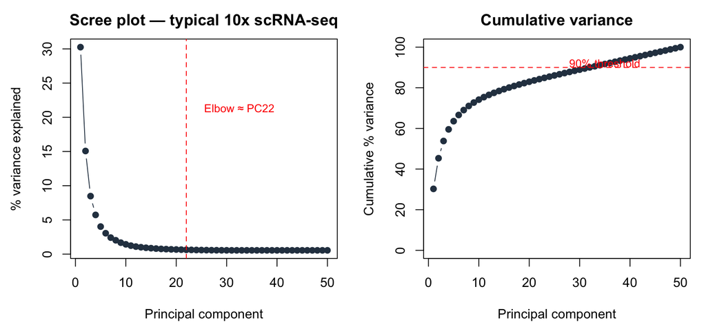

## Reading the scree plot

- The **elbow** is where each additional PC stops adding meaningful variance — usually between **PC15 and PC30** for 10x runs
- Cumulative variance is a sanity check, not a goal: a “90% rule” is misleading because the noise floor is high in scRNA-seq
- `ElbowPlot(seu, ndims = 50)` is the visual; `JackStraw()` is a permutation-based statistical alternative when you want a defensible cutoff

**Tip**

**When in doubt, lean high.** Going from 20 PCs to 30 PCs rarely hurts clustering and often recovers a subtype that 20 PCs collapses. Going from 30 to 50 mostly costs runtime.

## Loadings — which genes drive each PC?

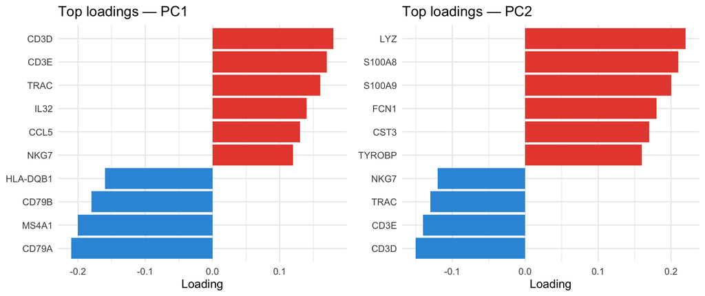

## Loadings — which genes drive each PC?

- **Loadings** are the weights that mix each gene into a PC. Big positive (or negative) loadings = genes moving cells along that axis.
- In the previous cartoon:
  - PC1 separates T-cell markers (`CD3D`, `CD3E`, `TRAC`) from B-cell markers (`CD79A`, `MS4A1`);
  - PC2 separates myeloid markers (`LYZ`, `S100A8`, `S100A9`) from lymphoid.
- Workflow tools:
  - `VizDimLoadings(seu, dims = 1:4)` for bar plots,
  - `DimHeatmap(seu, dims = 1:9, balanced = TRUE)` for a per-cell heatmap of the top loaders.
- This is the step where PCA earns its reputation as **interpretable**: t-SNE and UMAP cannot tell you *which genes* drive a separation — PCA can.

# Neighbour graph + graph-based clustering

## SNN graph → clusters (Louvain / Leiden)

- Build a **shared nearest-neighbor (SNN)** graph from the integrated PCs — each cell connects to its $k$ nearest neighbours, weighted by how many of those neighbours are *shared*
- **Cluster** the graph at a chosen resolution — with Seurat’s default **Louvain**, or the modern **Leiden** (preferred, but needs a Python dependency)
- The graph (not the gene matrix nor UMAP) is the object the clustering actually runs on

**Note**

**Louvain (default) vs. Leiden.**

- Seurat’s `FindClusters()` defaults to **Louvain** (`algorithm = 1`), and that is what the **workshop tutorials run** — for portability.
- **Leiden** (`algorithm = 4`) is the modern preferred refinement (it guarantees well-connected communities) but needs the `leidenalg` Python package via `reticulate`.
- Switching is the one-line `algorithm = 4` change once that dependency is installed.

## KNN — the building block

[figure not shown]

- Each cell’s identity is set by the cells it is **closest to** in PC space
- The KNN graph is the substrate the SNN refinement and Leiden/Louvain modularity all run on top of

## Why graph-based clustering instead of K-means?

- K-means assumes clusters are **roughly spherical and equally sized** — a poor match for scRNA-seq, where rare cell types coexist with abundant ones and clusters have irregular shapes in PC space
- K-means also requires you to know **k** in advance; for scRNA-seq the whole point is often *discovering* how many populations there are
- **Graph-based methods** (Louvain, Leiden) discover clusters as densely-connected communities, naturally handle uneven cluster sizes, and let resolution control granularity instead of $k$

**Note**

This is the same reason single-cell pipelines have largely abandoned hierarchical clustering on raw expression: graph methods scale to millions of cells, run in minutes, and respect the local geometry that PCA preserved.

## Graph-based clustering — step by step

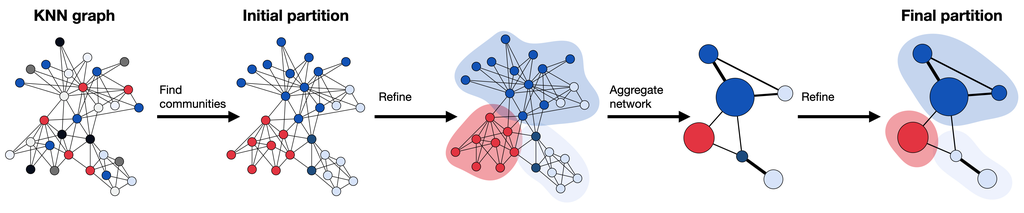

- Start with the **KNN graph** over cells in PCA space
- **Find communities** → initial partition; **refine** merges/splits based on modularity
- **Aggregate** the network, refine again → **final partition**

## Choosing a resolution

- A lower resolution means fewer clusters, higher means more
- No single “right” resolution exists — the question is *what cell types you want to resolve*
- Typical starting range: **0.4 – 1.2** for Louvain/Leiden on a 10–30k cell dataset
- Use **`clustree`** to visualize cluster stability across a sweep of resolutions
- Cross-check by inspecting markers of merged vs. split clusters

**Tip**

**Workflow.** Sweep resolutions, pick one where

- 1. `clustree` shows stable splits,
- 2. every cluster has at least a few defensible markers,
- 3. you can name biology for each. If you can’t name a cluster, it’s probably noise or technical.

**Important**

**Tutorial 02 runs deliberately *un-integrated*.** The ifnb dataset has two conditions (CTRL and STIM). Tutorial 02 runs PCA and clustering *without* integration — so your UMAP will show CTRL and STIM cells splitting into **mirror-image islands** rather than mixing by cell type. This is the expected, intentional outcome of Step 6 (“Diagnose the batch effect”). You will **count those islands and interpret what drives the split** before integration is introduced in Tutorial 05 / Lecture 05. On unintegrated data, resolution ≈ 0.5 typically yields **~15–20 clusters** — more than the ~13 annotatable cell types — because each cell type appears as a CTRL island and a STIM island.

## From PCs to a 2D picture for human consumption

- **PCA gave us a denoised ~30-D space; clustering already happened on the SNN graph in that space.** What’s left is a *picture* — a 2D embedding so we can show clusters, gradients, and trajectories on a slide.
- Two non-linear methods dominate:
  - **t-SNE** (van der Maaten & Hinton 2008) and
  - **UMAP** (McInnes, Healy & Melville 2018)
- Both share the same philosophy:
  - *In high-D:* “for each cell, who are its neighbours, and how similar?”
  - *In low-D:* “place points in 2D so those neighbour relationships are preserved”
- Crucially, t-SNE/UMAP are **visualizations, not analyses**. They don’t replace PCA or clustering — they sit on top of them.

## t-SNE: model neighbours as probabilities

[figure not shown]

## t-SNE: model neighbours as probabilities

- For each cell $i$, t-SNE turns *distances* to all other cells into a **probability distribution** $p_{j|i}$ — Gaussian in high-D, with bandwidth $\sigma_i$ chosen per cell so the effective neighbourhood size matches the user’s **perplexity**
- In the 2D embedding, the same idea gives $q_{j|i}$ from the current 2D positions
- t-SNE then **moves the 2D points** to minimize the Kullback–Leibler divergence

$$D_{KL}(P \| Q) = \sum_{i \neq j} p_{ij} \log \frac{p_{ij}}{q_{ij}}$$

- KL divergence is asymmetric — and that’s the point
- **Heavily penalised:** $p_{ij}$ large but $q_{ij}$ small → “you put true neighbours far apart” → strong attractive gradient pulls them together
- **Weakly penalised:** $p_{ij}$ small but $q_{ij}$ large → “you put unrelated cells nearby” → near-zero contribution to the loss

**Important**

This asymmetry is *the* most important property of t-SNE. It is why t-SNE preserves **local neighbourhoods** beautifully — and why **distances between clusters in a t-SNE plot are not meaningful**. Two clusters drawn far apart could be biologically very similar, and vice versa.

## UMAP

[figure not shown]

## UMAP

- For each cell
  - UMAP builds a **local weighted graph** out to its $k$ nearest neighbours, but normalises distances **per cell**
  - so points in sparse and dense regions of the data are still connected to *their own* local neighbours
- The local graphs are merged into one global **fuzzy weighted graph** ($w_{ij} = a + b - a \cdot b$)
- The 2D embedding starts from a spectral initialization (or random) and is optimised by stochastic gradient descent

## UMAP’s cross-entropy preserves more global structure

[figure not shown]

## UMAP’s cross-entropy preserves more global structure

$$CE = -\sum_{i,j} \left[ w_{ij} \log v_{ij} + (1 - w_{ij}) \log(1 - v_{ij}) \right]$$

- **Attraction term** $w_{ij} \log v_{ij}$: connected cells should stay close
- **Repulsion term** $(1 - w_{ij}) \log(1 - v_{ij})$: unconnected cells should stay apart
- Unlike KL, both errors are penalised → cluster *positions* and approximate inter-cluster distances are more faithful than t-SNE’s

**Note**

“More faithful” is not “fully faithful.” UMAP still warps global geometry; you should not measure trajectory length or biological similarity from UMAP coordinates alone.

## n_neighbors and min_dist, in practice

| Parameter | Seurat default | Effect |
| --- | --- | --- |
| `n.neighbors` | 30 | Soft “k” — local vs. global balance, like t-SNE’s perplexity |
| `min.dist` | 0.3 | Minimum distance between points in the embedding |

(Seurat’s `RunUMAP` defaults; the underlying Python `umap-learn` uses different defaults of 15 and 0.1, so don’t be surprised if other tutorials quote those.)

- **Small `n_neighbors` (5–10):** very local detail; clusters fragment more. **Large (30–50):** broader topology; subtypes may merge.
- **Small `min_dist` (≤ 0.1):** tight clusters with clear gaps — good for discrete cell types. **Large (0.4–0.8):** spread-out — good for continuous gradients (development, pseudotime).
- UMAP is **noticeably more stable** across `n_neighbors` than t-SNE is across perplexity — usually one well-chosen UMAP is enough; with t-SNE you really do want to sweep.

## Reading a UMAP responsibly

- What a UMAP **is** good for:
  - showing the cluster solution
  - mapping a known marker onto the cells (`FeaturePlot`)
  - spotting batch effects (color by sample after integration)
- What a UMAP is **not** good for
  - differential testing
  - distance-based statistics
  - conclusions about lineage relationships

**Warning**

**Three things a UMAP plot does NOT tell you:**

1. **Inter-cluster distance** — two clusters drawn far apart are not necessarily more dissimilar than two drawn close
2. **Cluster density** — apparent point density is heavily affected by `min_dist` and is not biological cell density
3. **Trajectory direction** — apparent gradients can be optimisation artefacts; use trajectory tools (Slingshot, Monocle, scVelo) for that question

**Tip**

**Build the intuition yourself.** Google PAIR’s interactive [Understanding UMAP](https://pair-code.github.io/understanding-umap/) lets you turn `n_neighbors`/`min_dist` and watch what the embedding does (and doesn’t) preserve; DataCamp’s [Understanding UMAP guide](https://www.datacamp.com/tutorial/understanding-umap-guide-to-dimensionality-reduction) is a written walkthrough. Highly recommended if these plots ever made your head spin.

# Recap

## What to remember from Lecture 02

- **PCA** on HVGs is the substrate every downstream step builds on — read the scree, read the loadings before you trust the embedding
- Build the **SNN graph** on the PCs, then cluster with **Louvain/Leiden** — graph-based methods beat K-means for scRNA-seq
- **t-SNE** preserves local neighbourhoods via KL divergence + the t-distribution; cluster *distances* in t-SNE are not meaningful
- **UMAP** preserves more global topology via cross-entropy on a fuzzy graph; today it’s the default
- Both are **visualizations, not analyses** — they sit on top of PCA + clustering, never replace them